# Desafío Python

Te compartimos un dataset de marketing de un banco portugues.

El objetivo es evaluar los datos, realizando un análisis descriptivo y evaluar una serie de modelos de clasificación y elegir el que mejor resultados obtiene prediciendo la columna 21 que representa si se suscribe al servicio correspondiente.

Se valora:

- La descripción del análisis realizado
- Las conclusiones de las decisiones tomadas
- La prolijidad del código.

Se requiere:

- Un notebook con el código correspondiente.
- Un video explicando las conclusiones de no más de 10min.

## Variables:

### Datos de clientes:

1 - age (numeric)

2 - job : type of job (categorical: 'admin.','blue-collar','entrepreneur','housemaid','management','retired','self-employed','services','student','technician','unemployed','unknown')

3 - marital : marital status (categorical: 'divorced','married','single','unknown'; note: 'divorced' means divorced or widowed)

4 - education (categorical: 'basic.4y','basic.6y','basic.9y','high.school','illiterate','professional.course','university.degree','unknown')

5 - default: has credit in default? (categorical: 'no','yes','unknown')

6 - housing: has housing loan? (categorical: 'no','yes','unknown')

7 - loan: has personal loan? (categorical: 'no','yes','unknown')

### Related with the last contact of the current campaign:

8 - contact: contact communication type (categorical: 'cellular','telephone')

9 - month: last contact month of year (categorical: 'jan', 'feb', 'mar', ..., 'nov', 'dec')

10 - day_of_week: last contact day of the week (categorical: 'mon','tue','wed','thu','fri')

11 - duration: last contact duration, in seconds (numeric). Important note: this attribute highly affects the output target (e.g., if duration=0 then y='no'). Yet, the duration is not known before a call is performed. Also, after the end of the call y is obviously known. Thus, this input should only be included for benchmark purposes and should be discarded if the intention is to have a realistic predictive model.

### Other attributes:

12 - campaign: number of contacts performed during this campaign and for this client (numeric, includes last contact)

13 - pdays: number of days that passed by after the client was last contacted from a previous campaign (numeric; 999 means client was not previously contacted)

14 - previous: number of contacts performed before this campaign and for this client (numeric)

15 - poutcome: outcome of the previous marketing campaign (categorical: 'failure','nonexistent','success')

### Social and economic context attributes

16 - emp.var.rate: employment variation rate - quarterly indicator (numeric)

17 - cons.price.idx: consumer price index - monthly indicator (numeric)

18 - cons.conf.idx: consumer confidence index - monthly indicator (numeric)

19 - euribor3m: euribor 3 month rate - daily indicator (numeric)

20 - nr.employed: number of employees - quarterly indicator (numeric)

### Output variable (desired target):

21 - y - has the client subscribed a term deposit? (binary: 'yes','no')

## I - Data onboarding

En esta primera sección, limpiamos y transformamos los datos para su posterior uso.

```python
# Data Analysis
import pandas as pd
import numpy as np
np.random.seed(201)
from tabulate import tabulate
import statistics

# Data Visualization
import matplotlib.pyplot as plt
import seaborn as sns
from sklearn.metrics import ConfusionMatrixDisplay, RocCurveDisplay
from sklearn.tree import plot_tree

# Statistical Modeling
import statsmodels.api as sm

# Preprocessing
from sklearn.preprocessing import LabelEncoder, scale, StandardScaler

# Machine Learning Models
from sklearn.model_selection import train_test_split
from sklearn.linear_model import Lasso, LassoCV, Ridge, RidgeCV
from sklearn.linear_model import LogisticRegression, LinearRegression
from sklearn.discriminant_analysis import LinearDiscriminantAnalysis
from sklearn.neighbors import KNeighborsClassifier
from sklearn.tree import DecisionTreeClassifier
from sklearn.ensemble import BaggingClassifier, RandomForestClassifier, GradientBoostingClassifier, AdaBoostClassifier

# Model Evaluation
from sklearn.metrics import mean_squared_error, accuracy_score, recall_score
from sklearn.metrics import confusion_matrix, roc_auc_score, accuracy_score, precision_score, mean_squared_error
from sklearn.metrics import roc_curve, make_scorer, auc

# Model Selection and Validation
from sklearn.model_selection import train_test_split, KFold, cross_val_score

# Utilities
from sklearn.utils import resample
from sklearn import datasets, metrics
```

```python
# Cargamos la data y vemos un overview.
data = pd.read_csv('bank-additional-full.csv', delimiter=';')
display(data.head())
print("DataFrame Info:")
data.info()
```

|  | age | job | marital | education | default | housing | loan | contact | month | day_of_week | ... | campaign | pdays | previous | poutcome | emp.var.rate | cons.price.idx | cons.conf.idx | euribor3m | nr.employed | y |
| --- | --- | --- | --- | --- | --- | --- | --- | --- | --- | --- | --- | --- | --- | --- | --- | --- | --- | --- | --- | --- | --- |
| 0 | 56 | housemaid | married | basic.4y | no | no | no | telephone | may | mon | ... | 1 | 999 | 0 | nonexistent | 1.1 | 93.994 | -36.4 | 4.857 | 5191.0 | no |
| 1 | 57 | services | married | high.school | unknown | no | no | telephone | may | mon | ... | 1 | 999 | 0 | nonexistent | 1.1 | 93.994 | -36.4 | 4.857 | 5191.0 | no |
| 2 | 37 | services | married | high.school | no | yes | no | telephone | may | mon | ... | 1 | 999 | 0 | nonexistent | 1.1 | 93.994 | -36.4 | 4.857 | 5191.0 | no |
| 3 | 40 | admin. | married | basic.6y | no | no | no | telephone | may | mon | ... | 1 | 999 | 0 | nonexistent | 1.1 | 93.994 | -36.4 | 4.857 | 5191.0 | no |
| 4 | 56 | services | married | high.school | no | no | yes | telephone | may | mon | ... | 1 | 999 | 0 | nonexistent | 1.1 | 93.994 | -36.4 | 4.857 | 5191.0 | no |

5 rows × 21 columns

```
DataFrame Info:
<class 'pandas.core.frame.DataFrame'>
RangeIndex: 41188 entries, 0 to 41187
Data columns (total 21 columns):
 #   Column          Non-Null Count  Dtype
---  ------          --------------  -----
 0   age             41188 non-null  int64
 1   job             41188 non-null  object
 2   marital         41188 non-null  object
 3   education       41188 non-null  object
 4   default         41188 non-null  object
 5   housing         41188 non-null  object
 6   loan            41188 non-null  object
 7   contact         41188 non-null  object
 8   month           41188 non-null  object
 9   day_of_week     41188 non-null  object
 10  duration        41188 non-null  int64
 11  campaign        41188 non-null  int64
 12  pdays           41188 non-null  int64
 13  previous        41188 non-null  int64
 14  poutcome        41188 non-null  object
 15  emp.var.rate    41188 non-null  float64
 16  cons.price.idx  41188 non-null  float64
 17  cons.conf.idx   41188 non-null  float64
 18  euribor3m       41188 non-null  float64
 19  nr.employed     41188 non-null  float64
 20  y               41188 non-null  object
dtypes: float64(5), int64(5), object(11)
memory usage: 6.6+ MB
```

## II - Data processing

### 1. Missing values

```python
print("\n Análisis de Missing Values:")
missing_values = data.isnull().sum()
print(missing_values)

if missing_values.sum() == 0:
    print("\n No hay datos faltantes en las columnas.")
else:
    print("\n Hay datos faltantes (NAs).")
```

```
 Análisis de Missing Values:
age               0
job               0
marital           0
education         0
default           0
housing           0
loan              0
contact           0
month             0
day_of_week       0
duration          0
campaign          0
pdays             0
previous          0
poutcome          0
emp.var.rate      0
cons.price.idx    0
cons.conf.idx     0
euribor3m         0
nr.employed       0
y                 0
dtype: int64

 No hay datos faltantes en las columnas.
```

Confirmamos que no hay missing values numéricos en ninguno de nuestras columnas.

```python
# Revisamos la cantidad de datos iniciales

print("\n Nuestra data inicial cuenta con",len(data), "observaciones")

# Revisamos las columnas que no tienen sentido que tengan valores negativos, para luego eliminar las observaciones irrelevantes.

check = ['age','duration','campaign','pdays','previous']

# Filtramos los valores negativos de las columnas especificadas.

data_processed = data[~(data[check] < 0).any(axis=1)]

# Controlamos cuantos datos nos quedaron

print("\n Eliminando datos que no tienen sentido, nuestra data final cuenta con", len(data_processed), "observaciones")
```

```
 Nuestra data inicial cuenta con 41188 observaciones

 Eliminando datos que no tienen sentido, nuestra data final cuenta con 41188 observaciones
```

Aunque no hay NAs, vemos que hay variables con valores 'unknown'. Procedemos a analizar qué tan frecuente son, para ver si podemos reemplazarlos por su moda.

```python
# Definimos las columnas a analizar
columns_to_analyze = ['job', 'marital', 'education', 'default', 'housing', 'loan']

# Creamos un diccionario para almacenar los resultados
unknown_counts = {}

# Calculamos la proporción de 'unknowns' para cada columna
for column in columns_to_analyze:
    unknown_count = (data_processed[column] == 'unknown').sum()
    total_count = len(data_processed)
    unknown_proportion = unknown_count / total_count
    unknown_counts[column] = unknown_proportion

# Creamos un DataFrame a partir del diccionario
unknown_counts_df = pd.DataFrame.from_dict(unknown_counts, orient='index', columns=['Proporción de NAs (unknown)'])

display(unknown_counts_df)
```

|  | Proporción de NAs (unknown) |
| --- | --- |
| job | 0.008012 |
| marital | 0.001942 |
| education | 0.042027 |
| default | 0.208726 |
| housing | 0.024036 |
| loan | 0.024036 |

Por ende, para todas las otras columnas (job, marital, education, housing, loan) procedemos más adelante a rellenar los datos con su moda.

### 2. Formateo de variables categóricas

#### A) Mapping

```python
data_processed_mapping = data_processed.copy()
```

```python
#Transformamos las variables categóricas a numéricas.

# Según la consigna, la columna 'duration' es altamente predictiva por lo que la dropeamos de la data que usaremos para predecir (data).

#data_processed.drop(columns=['duration'], inplace=True)

# Para 'job', las ordenamos en base al 'skill level'



job_mapping = {
    'unemployed': 0,
    'housemaid': 1,
    'blue-collar': 2,
    'admin.': 3,
    'self-employed': 4,
    'student': 5,
    'technician': 6,
    'retired': 7,
    'entrepreneur': 8,
    'services': 9,
    'management': 10,
    'unknown': 99999
}

data_processed_mapping['job'] = data_processed_mapping['job'].map(job_mapping)

# Para 'marital'
marital_mapping = {
    'single': 0,
    'married': 1,
    'divorced': 2,
    'unknown': 99999
}
data_processed_mapping['marital'] = data_processed_mapping['marital'].map(marital_mapping)

# Para 'education', codificamos mappeamos los valores:
education_mapping = {
    'illiterate': 0,
    'basic.4y': 1,
    'basic.6y': 2,
    'basic.9y': 3,
    'high.school': 4,
    'professional.course': 5,
    'university.degree': 6,
    'unknown': 99999
}
data_processed_mapping['education'] = data_processed_mapping['education'].map(education_mapping)

# Para 'default'
default_mapping = {
    'unknown': -1,
    'no': 0,
    'yes': 1
}
data_processed_mapping['default'] = data_processed_mapping['default'].map(default_mapping)

# Para 'housing'
housing_mapping = {
    'no': 0,
    'yes': 1,
    'unknown': 99999
}
data_processed_mapping['housing'] = data_processed_mapping['housing'].map(housing_mapping)

# Para 'loan'
loan_mapping = {
    'no': 0,
    'yes': 1,
    'unknown': 99999
}
data_processed_mapping['loan'] = data_processed_mapping['loan'].map(loan_mapping)

# Para 'contact', codificamos binariamente:
contact_mapping = {
    'telephone': 0,
    'cellular': 1
}
data_processed_mapping['contact'] = data_processed_mapping['contact'].map(contact_mapping)

# Para 'poutcome', codificamos mappeamos los valores:
poutcome_mapping = {
    'nonexistent': 0,
    'failure': 1,
    'success': 2
}
data_processed_mapping['poutcome'] = data_processed_mapping['poutcome'].map(poutcome_mapping)

# Para 'y'
y_mapping = {
    'no': 0,
    'yes': 1
}
data_processed_mapping['y'] = data_processed_mapping['y'].map(y_mapping)
```

```python
columns_to_process = ['job', 'marital', 'education', 'housing', 'loan', 'contact']

for column in columns_to_process:
    if column in data_processed_mapping.columns:
        # Check if the column is not empty
        if not data_processed_mapping[column].empty:
            most_frequent_value = data_processed_mapping[column].mode()[0]  # Find the mode value
            print(f'\n Para la columna {column}, la moda es {most_frequent_value}')

            # Print the unique values before replacement for debugging
            print(f'Valores únicos antes del remplazo {column}: {data_processed_mapping[column].unique()}')

            # Replace 'unknown' with the most frequent value, considering case and whitespace issues
            data_processed_mapping[column] = data_processed_mapping[column].replace(99999, most_frequent_value)

            # Print the unique values after replacement for debugging
            print(f'Valores únicos después del remplazo {column}: {data_processed_mapping[column].unique()}')
        else:
            print(f'\nLa columna {column} esá vacía.')
    else:
        print(f'\nLa columna {column} no existe en el dataframe.')
```

```
 Para la columna job, la moda es 3
Valores únicos antes del remplazo job: [    1     9     3     2     6     7    10     0     4 99999     8     5]
Valores únicos después del remplazo job: [ 1  9  3  2  6  7 10  0  4  8  5]

 Para la columna marital, la moda es 1
Valores únicos antes del remplazo marital: [    1     0     2 99999]
Valores únicos después del remplazo marital: [1 0 2]

 Para la columna education, la moda es 6
Valores únicos antes del remplazo education: [    1     4     2     3     5 99999     6     0]
Valores únicos después del remplazo education: [1 4 2 3 5 6 0]

 Para la columna housing, la moda es 1
Valores únicos antes del remplazo housing: [    0     1 99999]
Valores únicos después del remplazo housing: [0 1]

 Para la columna loan, la moda es 0
Valores únicos antes del remplazo loan: [    0     1 99999]
Valores únicos después del remplazo loan: [0 1]

 Para la columna contact, la moda es 1
Valores únicos antes del remplazo contact: [0 1]
Valores únicos después del remplazo contact: [0 1]
```

```python
# Definimos las columnas a analizar
columns_to_analyze = ['job', 'marital', 'education', 'default', 'housing', 'loan']

# Creamos un diccionario para almacenar los resultados de 'unknowns'
unknown_counts = {}

# Calculamos la proporción de 'unknowns' para cada columna
for column in columns_to_analyze:
    unknown_count = (data_processed_mapping[column] == 'unknown').sum()
    total_count = len(data_processed_mapping)
    unknown_proportion = unknown_count / total_count
    unknown_counts[column] = unknown_proportion

# Creamos un DataFrame a partir del diccionario
unknown_counts_df = pd.DataFrame.from_dict(unknown_counts, orient='index', columns=['Proporción de "unknown"'])

print("Proporción de 'unknown' en cada columna:")
display(unknown_counts_df)

# Creamos un diccionario para almacenar los resultados de valores vacíos
nan_counts = {}

# Calculamos la proporción de NaNs para cada columna
for column in columns_to_analyze:
    nan_count = data_processed_mapping[column].isna().sum()
    total_count = len(data_processed_mapping)
    nan_proportion = nan_count / total_count
    nan_counts[column] = nan_proportion

# Creamos un DataFrame a partir del diccionario
nan_counts_df = pd.DataFrame.from_dict(nan_counts, orient='index', columns=['Proporción de NaNs'])

print("Proporción de NaNs en cada columna:")
display(nan_counts_df)
```

```
Proporción de 'unknown' en cada columna:
```

|  | Proporción de "unknown" |
| --- | --- |
| job | 0.0 |
| marital | 0.0 |
| education | 0.0 |
| default | 0.0 |
| housing | 0.0 |
| loan | 0.0 |

```
Proporción de NaNs en cada columna:
```

|  | Proporción de NaNs |
| --- | --- |
| job | 0.0 |
| marital | 0.0 |
| education | 0.0 |
| default | 0.0 |
| housing | 0.0 |
| loan | 0.0 |

Una vez mappeados los valores, procedemos a reemplazar los NAs previamente identificados.

#### B) Label Encoding

```python
# Para los días de las variables temporales, usamos label encoding para mantener un approach agnótisco con los datos.

# Creamos un diccionario para registrar los encodings.
label_encoders = {}

# Hacemos label encoding para la variable categórica 'month'
month_encoder = LabelEncoder()
data_processed_mapping['month'] = month_encoder.fit_transform(data_processed_mapping['month'])
label_encoders['month'] = dict(zip(month_encoder.classes_, month_encoder.transform(month_encoder.classes_)))

# Hacemos label encoding para la variable categórica 'day_of_week'
day_of_week_encoder = LabelEncoder()
data_processed_mapping['day_of_week'] = day_of_week_encoder.fit_transform(data_processed_mapping['day_of_week'])
label_encoders['day_of_week'] = dict(zip(day_of_week_encoder.classes_, day_of_week_encoder.transform(day_of_week_encoder.classes_)))

print("\nLabel Encoders:")
print(label_encoders)
```

```
Label Encoders:
{'month': {'apr': 0, 'aug': 1, 'dec': 2, 'jul': 3, 'jun': 4, 'mar': 5, 'may': 6, 'nov': 7, 'oct': 8, 'sep': 9}, 'day_of_week': {'fri': 0, 'mon': 1, 'thu': 2, 'tue': 3, 'wed': 4}}
```

```python
# Vemos que la variable 'pdays' contiene muchos 999, implicando que muchos no fueron contactados. En vez de descartar la variable, la reemplazamos por un '-1', así mantenemos esa información y la del último contacto con el cliente.
data_processed_mapping['pdays'] = data_processed_mapping['pdays'].replace(999, -1)
```

```python
# Vemos los cambios

display(data)
display(data_processed_mapping)
```

|  | age | job | marital | education | default | housing | loan | contact | month | day_of_week | ... | campaign | pdays | previous | poutcome | emp.var.rate | cons.price.idx | cons.conf.idx | euribor3m | nr.employed | y |
| --- | --- | --- | --- | --- | --- | --- | --- | --- | --- | --- | --- | --- | --- | --- | --- | --- | --- | --- | --- | --- | --- |
| 0 | 56 | housemaid | married | basic.4y | no | no | no | telephone | may | mon | ... | 1 | 999 | 0 | nonexistent | 1.1 | 93.994 | -36.4 | 4.857 | 5191.0 | no |
| 1 | 57 | services | married | high.school | unknown | no | no | telephone | may | mon | ... | 1 | 999 | 0 | nonexistent | 1.1 | 93.994 | -36.4 | 4.857 | 5191.0 | no |
| 2 | 37 | services | married | high.school | no | yes | no | telephone | may | mon | ... | 1 | 999 | 0 | nonexistent | 1.1 | 93.994 | -36.4 | 4.857 | 5191.0 | no |
| 3 | 40 | admin. | married | basic.6y | no | no | no | telephone | may | mon | ... | 1 | 999 | 0 | nonexistent | 1.1 | 93.994 | -36.4 | 4.857 | 5191.0 | no |
| 4 | 56 | services | married | high.school | no | no | yes | telephone | may | mon | ... | 1 | 999 | 0 | nonexistent | 1.1 | 93.994 | -36.4 | 4.857 | 5191.0 | no |
| ... | ... | ... | ... | ... | ... | ... | ... | ... | ... | ... | ... | ... | ... | ... | ... | ... | ... | ... | ... | ... | ... |
| 41183 | 73 | retired | married | professional.course | no | yes | no | cellular | nov | fri | ... | 1 | 999 | 0 | nonexistent | -1.1 | 94.767 | -50.8 | 1.028 | 4963.6 | yes |
| 41184 | 46 | blue-collar | married | professional.course | no | no | no | cellular | nov | fri | ... | 1 | 999 | 0 | nonexistent | -1.1 | 94.767 | -50.8 | 1.028 | 4963.6 | no |
| 41185 | 56 | retired | married | university.degree | no | yes | no | cellular | nov | fri | ... | 2 | 999 | 0 | nonexistent | -1.1 | 94.767 | -50.8 | 1.028 | 4963.6 | no |
| 41186 | 44 | technician | married | professional.course | no | no | no | cellular | nov | fri | ... | 1 | 999 | 0 | nonexistent | -1.1 | 94.767 | -50.8 | 1.028 | 4963.6 | yes |
| 41187 | 74 | retired | married | professional.course | no | yes | no | cellular | nov | fri | ... | 3 | 999 | 1 | failure | -1.1 | 94.767 | -50.8 | 1.028 | 4963.6 | no |

41188 rows × 21 columns

|  | age | job | marital | education | default | housing | loan | contact | month | day_of_week | ... | campaign | pdays | previous | poutcome | emp.var.rate | cons.price.idx | cons.conf.idx | euribor3m | nr.employed | y |
| --- | --- | --- | --- | --- | --- | --- | --- | --- | --- | --- | --- | --- | --- | --- | --- | --- | --- | --- | --- | --- | --- |
| 0 | 56 | 1 | 1 | 1 | 0 | 0 | 0 | 0 | 6 | 1 | ... | 1 | -1 | 0 | 0 | 1.1 | 93.994 | -36.4 | 4.857 | 5191.0 | 0 |
| 1 | 57 | 9 | 1 | 4 | -1 | 0 | 0 | 0 | 6 | 1 | ... | 1 | -1 | 0 | 0 | 1.1 | 93.994 | -36.4 | 4.857 | 5191.0 | 0 |
| 2 | 37 | 9 | 1 | 4 | 0 | 1 | 0 | 0 | 6 | 1 | ... | 1 | -1 | 0 | 0 | 1.1 | 93.994 | -36.4 | 4.857 | 5191.0 | 0 |
| 3 | 40 | 3 | 1 | 2 | 0 | 0 | 0 | 0 | 6 | 1 | ... | 1 | -1 | 0 | 0 | 1.1 | 93.994 | -36.4 | 4.857 | 5191.0 | 0 |
| 4 | 56 | 9 | 1 | 4 | 0 | 0 | 1 | 0 | 6 | 1 | ... | 1 | -1 | 0 | 0 | 1.1 | 93.994 | -36.4 | 4.857 | 5191.0 | 0 |
| ... | ... | ... | ... | ... | ... | ... | ... | ... | ... | ... | ... | ... | ... | ... | ... | ... | ... | ... | ... | ... | ... |
| 41183 | 73 | 7 | 1 | 5 | 0 | 1 | 0 | 1 | 7 | 0 | ... | 1 | -1 | 0 | 0 | -1.1 | 94.767 | -50.8 | 1.028 | 4963.6 | 1 |
| 41184 | 46 | 2 | 1 | 5 | 0 | 0 | 0 | 1 | 7 | 0 | ... | 1 | -1 | 0 | 0 | -1.1 | 94.767 | -50.8 | 1.028 | 4963.6 | 0 |
| 41185 | 56 | 7 | 1 | 6 | 0 | 1 | 0 | 1 | 7 | 0 | ... | 2 | -1 | 0 | 0 | -1.1 | 94.767 | -50.8 | 1.028 | 4963.6 | 0 |
| 41186 | 44 | 6 | 1 | 5 | 0 | 0 | 0 | 1 | 7 | 0 | ... | 1 | -1 | 0 | 0 | -1.1 | 94.767 | -50.8 | 1.028 | 4963.6 | 1 |
| 41187 | 74 | 7 | 1 | 5 | 0 | 1 | 0 | 1 | 7 | 0 | ... | 3 | -1 | 1 | 1 | -1.1 | 94.767 | -50.8 | 1.028 | 4963.6 | 0 |

41188 rows × 21 columns

```python
# Confirmamos qu no hayan quedados NaNs
nan_counts = {}

for column in data_processed_mapping.columns:
    nan_count = data_processed_mapping[column].isna().sum()
    total_count = len(data_processed_mapping)
    nan_proportion = nan_count / total_count
    nan_counts[column] = nan_proportion

nan_counts_df = pd.DataFrame.from_dict(nan_counts, orient='index', columns=['Proportion of NaNs'])

display(nan_counts_df)
```

|  | Proportion of NaNs |
| --- | --- |
| age | 0.0 |
| job | 0.0 |
| marital | 0.0 |
| education | 0.0 |
| default | 0.0 |
| housing | 0.0 |
| loan | 0.0 |
| contact | 0.0 |
| month | 0.0 |
| day_of_week | 0.0 |
| duration | 0.0 |
| campaign | 0.0 |
| pdays | 0.0 |
| previous | 0.0 |
| poutcome | 0.0 |
| emp.var.rate | 0.0 |
| cons.price.idx | 0.0 |
| cons.conf.idx | 0.0 |
| euribor3m | 0.0 |
| nr.employed | 0.0 |
| y | 0.0 |

Ahora revisamos que no hayan grandes outliers ensuciando nuestras predicciones.

## III - Análisis descriptivo

### A) Estadísticas descriptivas

```python
# Vemos una estadísticas iniciales.

data_processed_mapping_with_duration = data_processed_mapping.copy()

data_processed_mapping = data_processed_mapping.drop('duration', axis=1)

print("Descriptive Statistics:")
display(data_processed_mapping.describe().T)
```

```
Descriptive Statistics:
```

|  | count | mean | std | min | 25% | 50% | 75% | max |
| --- | --- | --- | --- | --- | --- | --- | --- | --- |
| age | 41188.0 | 40.024060 | 10.421250 | 17.000 | 32.000 | 38.000 | 47.000 | 98.000 |
| job | 41188.0 | 4.637030 | 2.821696 | 0.000 | 2.000 | 3.000 | 6.000 | 10.000 |
| marital | 41188.0 | 0.831116 | 0.603589 | 0.000 | 0.000 | 1.000 | 1.000 | 2.000 |
| education | 41188.0 | 4.238225 | 1.645985 | 0.000 | 3.000 | 4.000 | 6.000 | 6.000 |
| default | 41188.0 | -0.208653 | 0.406530 | -1.000 | 0.000 | 0.000 | 0.000 | 1.000 |
| housing | 41188.0 | 0.547878 | 0.497708 | 0.000 | 0.000 | 1.000 | 1.000 | 1.000 |
| loan | 41188.0 | 0.151695 | 0.358729 | 0.000 | 0.000 | 0.000 | 0.000 | 1.000 |
| contact | 41188.0 | 0.634748 | 0.481507 | 0.000 | 0.000 | 1.000 | 1.000 | 1.000 |
| month | 41188.0 | 4.230868 | 2.320025 | 0.000 | 3.000 | 4.000 | 6.000 | 9.000 |
| day_of_week | 41188.0 | 2.004613 | 1.397575 | 0.000 | 1.000 | 2.000 | 3.000 | 4.000 |
| campaign | 41188.0 | 2.567593 | 2.770014 | 1.000 | 1.000 | 2.000 | 3.000 | 56.000 |
| pdays | 41188.0 | -0.741988 | 1.510327 | -1.000 | -1.000 | -1.000 | -1.000 | 27.000 |
| previous | 41188.0 | 0.172963 | 0.494901 | 0.000 | 0.000 | 0.000 | 0.000 | 7.000 |
| poutcome | 41188.0 | 0.169904 | 0.455754 | 0.000 | 0.000 | 0.000 | 0.000 | 2.000 |
| emp.var.rate | 41188.0 | 0.081886 | 1.570960 | -3.400 | -1.800 | 1.100 | 1.400 | 1.400 |
| cons.price.idx | 41188.0 | 93.575664 | 0.578840 | 92.201 | 93.075 | 93.749 | 93.994 | 94.767 |
| cons.conf.idx | 41188.0 | -40.502600 | 4.628198 | -50.800 | -42.700 | -41.800 | -36.400 | -26.900 |
| euribor3m | 41188.0 | 3.621291 | 1.734447 | 0.634 | 1.344 | 4.857 | 4.961 | 5.045 |
| nr.employed | 41188.0 | 5167.035911 | 72.251528 | 4963.600 | 5099.100 | 5191.000 | 5228.100 | 5228.100 |
| y | 41188.0 | 0.112654 | 0.316173 | 0.000 | 0.000 | 0.000 | 0.000 | 1.000 |

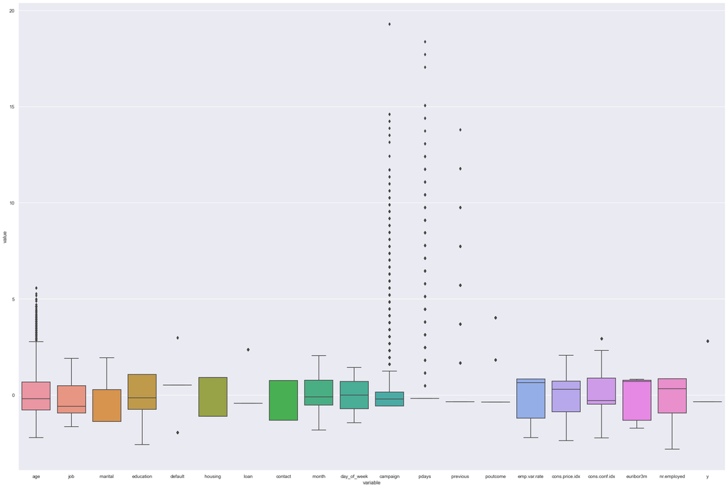

```python
# Hacemos un Box Plot para ver:

# Copiamos la data, para graficarla normalizada
normalized_data = data_processed_mapping.copy()

# Normalizamos
normalized_data = (normalized_data - normalized_data.mean()) / normalized_data.std()

# Graficamos
sns.set(rc={'figure.figsize':(30,20)})
sns.boxplot(x="variable", y="value", data=pd.melt(normalized_data))
plt.show()
```

Vemos que un par de variables tienen una varianza muy grande, por lo que conviene recortarlas.

- age
- campaign
- pdays
- previous

Hacemos zoom en las variables problemáticas.

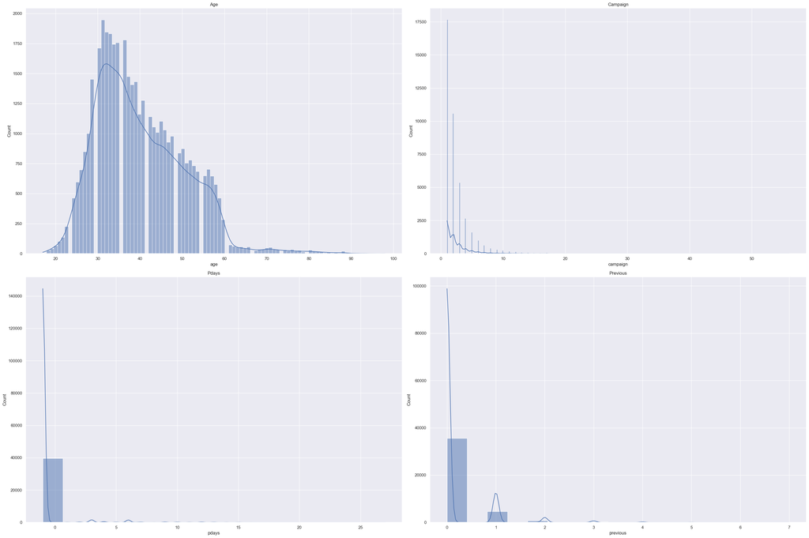

```python
plt.subplot(2, 2, 1)
sns.histplot(data_processed_mapping['age'], kde=True)
plt.title('Age')
plt.subplot(2, 2, 2)
sns.histplot(data_processed_mapping['campaign'], kde=True)
plt.title('Campaign')
plt.subplot(2, 2, 3)
sns.histplot(data_processed_mapping['pdays'], kde=True)
plt.title('Pdays')
plt.subplot(2, 2, 4)
sns.histplot(data_processed_mapping['previous'], kde=True)
plt.title('Previous')

plt.tight_layout()
plt.show()
```

Vemos que las variables 'campaign', 'pdays' y 'previous' presentan una gran concentración de datos en sus colas:

Recordando:

'campaign': number of contacts performed during this campaign and for this client (numeric, includes last contact).

'pdays': number of days that passed by after the client was last contacted from a previous campaign (numeric; 999 means client was not previously contacted).

'previous': number of contacts performed before this campaign and for this client (numeric).

```python
# Definimos las columnas a filtrar

columnas_a_filtrar = ['age', 'campaign', 'pdays', 'previous']

def remove_top_10_percent(df, columns):
    P90 = df[columns].quantile(0.9)
    filter_condition = ~(df[columns] > P90).any(axis=1)
    return df[filter_condition]

# Filtramos
data_cut = remove_top_10_percent(data_processed_mapping, columnas_a_filtrar)

# Revisamos las estadísticas descriptivas
print("Estadísticas descriptivas de la data procesada:")
display(data_processed_mapping.describe().T)

print("\nEstadísticas descriptivas de la data procesada y filtrada:")
display(data_cut.describe().T)
```

```
Estadísticas descriptivas de la data procesada:
```

|  | count | mean | std | min | 25% | 50% | 75% | max |
| --- | --- | --- | --- | --- | --- | --- | --- | --- |
| age | 41188.0 | 40.024060 | 10.421250 | 17.000 | 32.000 | 38.000 | 47.000 | 98.000 |
| job | 41188.0 | 4.637030 | 2.821696 | 0.000 | 2.000 | 3.000 | 6.000 | 10.000 |
| marital | 41188.0 | 0.831116 | 0.603589 | 0.000 | 0.000 | 1.000 | 1.000 | 2.000 |
| education | 41188.0 | 4.238225 | 1.645985 | 0.000 | 3.000 | 4.000 | 6.000 | 6.000 |
| default | 41188.0 | -0.208653 | 0.406530 | -1.000 | 0.000 | 0.000 | 0.000 | 1.000 |
| housing | 41188.0 | 0.547878 | 0.497708 | 0.000 | 0.000 | 1.000 | 1.000 | 1.000 |
| loan | 41188.0 | 0.151695 | 0.358729 | 0.000 | 0.000 | 0.000 | 0.000 | 1.000 |
| contact | 41188.0 | 0.634748 | 0.481507 | 0.000 | 0.000 | 1.000 | 1.000 | 1.000 |
| month | 41188.0 | 4.230868 | 2.320025 | 0.000 | 3.000 | 4.000 | 6.000 | 9.000 |
| day_of_week | 41188.0 | 2.004613 | 1.397575 | 0.000 | 1.000 | 2.000 | 3.000 | 4.000 |
| campaign | 41188.0 | 2.567593 | 2.770014 | 1.000 | 1.000 | 2.000 | 3.000 | 56.000 |
| pdays | 41188.0 | -0.741988 | 1.510327 | -1.000 | -1.000 | -1.000 | -1.000 | 27.000 |
| previous | 41188.0 | 0.172963 | 0.494901 | 0.000 | 0.000 | 0.000 | 0.000 | 7.000 |
| poutcome | 41188.0 | 0.169904 | 0.455754 | 0.000 | 0.000 | 0.000 | 0.000 | 2.000 |
| emp.var.rate | 41188.0 | 0.081886 | 1.570960 | -3.400 | -1.800 | 1.100 | 1.400 | 1.400 |
| cons.price.idx | 41188.0 | 93.575664 | 0.578840 | 92.201 | 93.075 | 93.749 | 93.994 | 94.767 |
| cons.conf.idx | 41188.0 | -40.502600 | 4.628198 | -50.800 | -42.700 | -41.800 | -36.400 | -26.900 |
| euribor3m | 41188.0 | 3.621291 | 1.734447 | 0.634 | 1.344 | 4.857 | 4.961 | 5.045 |
| nr.employed | 41188.0 | 5167.035911 | 72.251528 | 4963.600 | 5099.100 | 5191.000 | 5228.100 | 5228.100 |
| y | 41188.0 | 0.112654 | 0.316173 | 0.000 | 0.000 | 0.000 | 0.000 | 1.000 |

```
Estadísticas descriptivas de la data procesada y filtrada:
```

|  | count | mean | std | min | 25% | 50% | 75% | max |
| --- | --- | --- | --- | --- | --- | --- | --- | --- |
| age | 32982.0 | 38.094779 | 8.217699 | 17.000 | 32.000 | 37.000 | 44.000 | 55.000 |
| job | 32982.0 | 4.558365 | 2.826567 | 0.000 | 2.000 | 3.000 | 6.000 | 10.000 |
| marital | 32982.0 | 0.808987 | 0.605470 | 0.000 | 0.000 | 1.000 | 1.000 | 2.000 |
| education | 32982.0 | 4.257747 | 1.601653 | 0.000 | 3.000 | 4.000 | 6.000 | 6.000 |
| default | 32982.0 | -0.206173 | 0.404787 | -1.000 | 0.000 | 0.000 | 0.000 | 1.000 |
| housing | 32982.0 | 0.548147 | 0.497684 | 0.000 | 0.000 | 1.000 | 1.000 | 1.000 |
| loan | 32982.0 | 0.153023 | 0.360015 | 0.000 | 0.000 | 0.000 | 0.000 | 1.000 |
| contact | 32982.0 | 0.625735 | 0.483940 | 0.000 | 0.000 | 1.000 | 1.000 | 1.000 |
| month | 32982.0 | 4.257656 | 2.286573 | 0.000 | 3.000 | 4.000 | 6.000 | 9.000 |
| day_of_week | 32982.0 | 2.010521 | 1.397817 | 0.000 | 1.000 | 2.000 | 3.000 | 4.000 |
| campaign | 32982.0 | 1.954096 | 1.129746 | 1.000 | 1.000 | 2.000 | 3.000 | 5.000 |
| pdays | 32982.0 | -1.000000 | 0.000000 | -1.000 | -1.000 | -1.000 | -1.000 | -1.000 |
| previous | 32982.0 | 0.097326 | 0.296405 | 0.000 | 0.000 | 0.000 | 0.000 | 1.000 |
| poutcome | 32982.0 | 0.097326 | 0.296405 | 0.000 | 0.000 | 0.000 | 0.000 | 1.000 |
| emp.var.rate | 32982.0 | 0.173789 | 1.505421 | -3.400 | -1.800 | 1.100 | 1.400 | 1.400 |
| cons.price.idx | 32982.0 | 93.578863 | 0.556986 | 92.201 | 93.075 | 93.444 | 93.994 | 94.767 |
| cons.conf.idx | 32982.0 | -40.710133 | 4.428227 | -50.800 | -42.700 | -41.800 | -36.400 | -26.900 |
| euribor3m | 32982.0 | 3.739932 | 1.660803 | 0.634 | 1.405 | 4.857 | 4.961 | 5.045 |
| nr.employed | 32982.0 | 5173.596013 | 64.816146 | 4963.600 | 5099.100 | 5191.000 | 5228.100 | 5228.100 |
| y | 32982.0 | 0.089291 | 0.285168 | 0.000 | 0.000 | 0.000 | 0.000 | 1.000 |

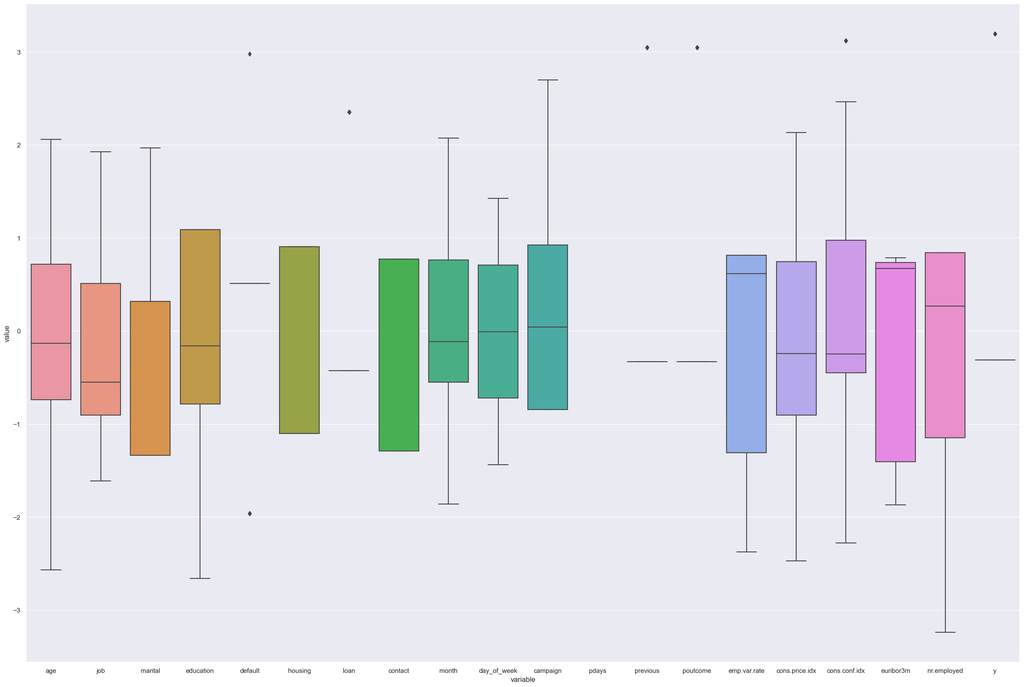

```python
# Revisamos gráficamente:

# Hacemos un Box Plot para ver:

# Copiamos la data, para graficarla normalizada
normalized_data_cut = data_cut.copy()

# Normalizamos
normalized_data_cut = (normalized_data_cut - normalized_data_cut.mean()) / normalized_data_cut.std()

# Graficamos
sns.set(rc={'figure.figsize':(30,20)})
sns.boxplot(x="variable", y="value", data=pd.melt(normalized_data_cut))
plt.show()
```

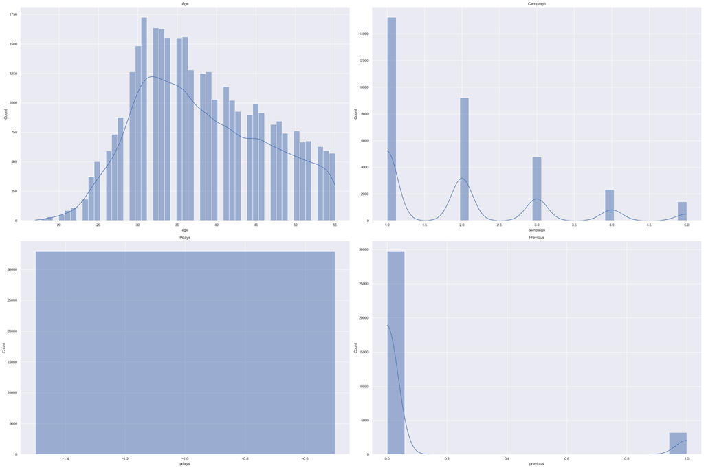

```python
plt.subplot(2, 2, 1)
sns.histplot(data_cut['age'], kde=True)
plt.title('Age')
plt.subplot(2, 2, 2)
sns.histplot(data_cut['campaign'], kde=True)
plt.title('Campaign')
plt.subplot(2, 2, 3)
sns.histplot(data_cut['pdays'], kde=True)
plt.title('Pdays')
plt.subplot(2, 2, 4)
sns.histplot(data_cut['previous'], kde=True)
plt.title('Previous')

plt.tight_layout()
plt.show()
```

### B) Tabla de correlaciones

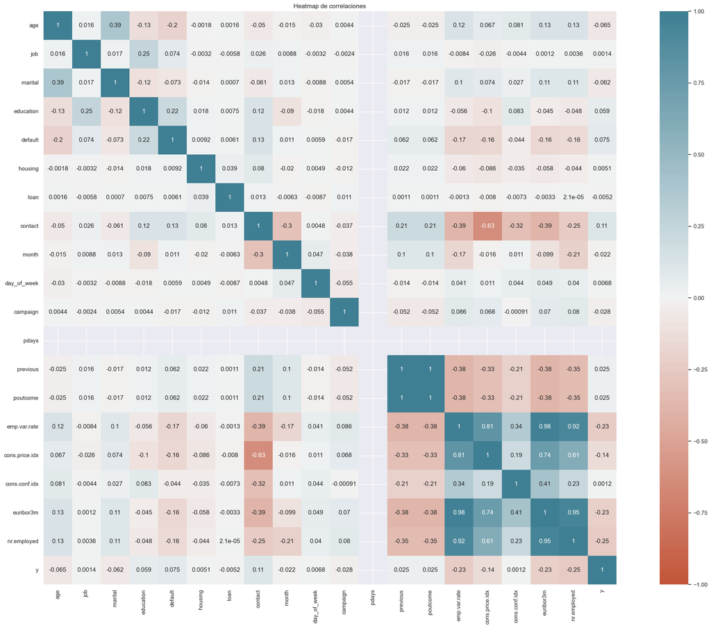

```python
corr = data_cut.corr()

ax = sns.heatmap(
    corr,
    vmin=-1, vmax=1, center=0, annot = True,
    cmap=sns.diverging_palette(20, 220, n=200),
    square=True
)
#Sumamos el título
plt.title("Heatmap de correlaciones")
```

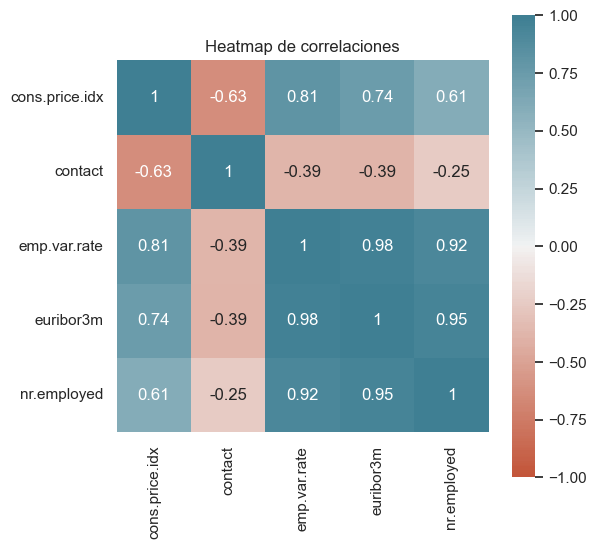

```python
corr_col = ['cons.price.idx', 'contact', 'emp.var.rate', 'euribor3m', 'nr.employed']

# Create the DataFrame with these columns.
data_high_corr = data_cut[corr_col]

# Calculate the correlation.
high_corr = data_high_corr.corr()

# Create a smaller figure for the heatmap.
plt.figure(figsize=(6, 6)) # Adjusted to make the graph smaller

ax = sns.heatmap(
    high_corr,
    vmin=-1, vmax=1, center=0, annot=True,
    cmap=sns.diverging_palette(20, 220, n=200),
    square=True
)

# Add title
plt.title("Heatmap de correlaciones")

# Show the plot
plt.show()
```

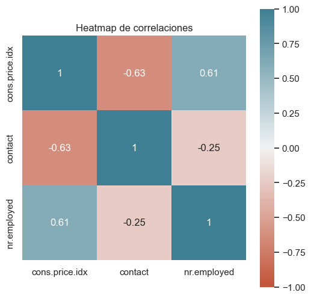

```python
corr_col = ['cons.price.idx', 'contact', 'nr.employed']

# Create the DataFrame with these columns.
data_high_corr2 = data_cut[corr_col]

# Calculate the correlation.
high_corr2 = data_high_corr2.corr()

# Create a smaller figure for the heatmap.
plt.figure(figsize=(6, 6)) # Adjusted to make the graph smaller

ax = sns.heatmap(
    high_corr2,
    vmin=-1, vmax=1, center=0, annot=True,
    cmap=sns.diverging_palette(20, 220, n=200),
    square=True
)

# Add title
plt.title("Heatmap de correlaciones")

# Show the plot
plt.show()
```

Vemos unas correlaciones aceptables.

```python
data_cut_final = data_cut.drop('pdays', axis=1)
data_cut_final = data_cut.drop('euribor3m', axis=1)
data_cut_final = data_cut.drop('emp.var.rate', axis=1)

display(data_cut_final.describe().T)
```

|  | count | mean | std | min | 25% | 50% | 75% | max |
| --- | --- | --- | --- | --- | --- | --- | --- | --- |
| age | 32982.0 | 38.094779 | 8.217699 | 17.000 | 32.000 | 37.000 | 44.000 | 55.000 |
| job | 32982.0 | 4.558365 | 2.826567 | 0.000 | 2.000 | 3.000 | 6.000 | 10.000 |
| marital | 32982.0 | 0.808987 | 0.605470 | 0.000 | 0.000 | 1.000 | 1.000 | 2.000 |
| education | 32982.0 | 4.257747 | 1.601653 | 0.000 | 3.000 | 4.000 | 6.000 | 6.000 |
| default | 32982.0 | -0.206173 | 0.404787 | -1.000 | 0.000 | 0.000 | 0.000 | 1.000 |
| housing | 32982.0 | 0.548147 | 0.497684 | 0.000 | 0.000 | 1.000 | 1.000 | 1.000 |
| loan | 32982.0 | 0.153023 | 0.360015 | 0.000 | 0.000 | 0.000 | 0.000 | 1.000 |
| contact | 32982.0 | 0.625735 | 0.483940 | 0.000 | 0.000 | 1.000 | 1.000 | 1.000 |
| month | 32982.0 | 4.257656 | 2.286573 | 0.000 | 3.000 | 4.000 | 6.000 | 9.000 |
| day_of_week | 32982.0 | 2.010521 | 1.397817 | 0.000 | 1.000 | 2.000 | 3.000 | 4.000 |
| campaign | 32982.0 | 1.954096 | 1.129746 | 1.000 | 1.000 | 2.000 | 3.000 | 5.000 |
| pdays | 32982.0 | -1.000000 | 0.000000 | -1.000 | -1.000 | -1.000 | -1.000 | -1.000 |
| previous | 32982.0 | 0.097326 | 0.296405 | 0.000 | 0.000 | 0.000 | 0.000 | 1.000 |
| poutcome | 32982.0 | 0.097326 | 0.296405 | 0.000 | 0.000 | 0.000 | 0.000 | 1.000 |
| cons.price.idx | 32982.0 | 93.578863 | 0.556986 | 92.201 | 93.075 | 93.444 | 93.994 | 94.767 |
| cons.conf.idx | 32982.0 | -40.710133 | 4.428227 | -50.800 | -42.700 | -41.800 | -36.400 | -26.900 |
| euribor3m | 32982.0 | 3.739932 | 1.660803 | 0.634 | 1.405 | 4.857 | 4.961 | 5.045 |
| nr.employed | 32982.0 | 5173.596013 | 64.816146 | 4963.600 | 5099.100 | 5191.000 | 5228.100 | 5228.100 |
| y | 32982.0 | 0.089291 | 0.285168 | 0.000 | 0.000 | 0.000 | 0.000 | 1.000 |

Con la data ya limpia, podemos proceder a la predicción de la columna 21.

## IV - Evaluación de modelos

Una vez limpiada la data, procedemos a crear tres funciones que nos permitirán evaluar varios modelos, para elegir el óptimo

### A) Función 'evalua_metodo'

Función para evaluar distintos métodos de acuerdo a un par de métricas de interés.

La función ajusta el modelo con los datos de entrenamiento (x_train, y_train) y calcular la matriz de confusión, los valores de AUC asociados, el Accuracy score de cada método, asi como la precisión y el ECM).

Consideramos varios métodos, tales como Regresión Logística (LR), Vecinos cercanos (KNN), Árboles de decisión, Análisis discriminante lineal (LDA), Bagging, Random Forest, Adaboost

```python
def evalua_metodo(X_train, X_test, Y_train, Y_test, modelo, vecinos=2, depth=1, b_estimators=5, features=2):
    '''
    La función ajusta el modelo con los datos de entrenamiento (x_train, y_train) y
    calcular la matriz de confusión, los valores de
    AUC asociados, el Accuracy score de cada método, asi como la precisión y el ECM).

    Input:

        x_train: Datos de entrenamiento (características) - Conjunto de entrenamiento.
        x_test: Datos de prueba (características) - Conjunto de prueba.
        y_train: Etiquetas de entrenamiento - Valores objetivo del conjunto de entrenamiento.
        y_test: Etiquetas de prueba - Valores objetivo del conjunto de prueba.
        modelo: Modelo de clasificación a evaluar (por ejemplo, LogisticRegression, LinearDiscriminantAnalysis, KNeighborsClassifier,
        DecisionTreeClassifier, BaggingClassifier, RandomForestClassifier, AdaBoostClassifier).
        vecinos=2: Parámetro vecinos (número de vecinos mas cercanos) para ajustar el modelo (por defecto, 2).
        depth: profundidad del árbol, cantidad de nodos en DecisionTreeClassifier
        b_estimators: número de muestras en BaggingClassifier
        features: cantidad de variables en RandomForestClassifier

    Output:

        df_metrics: DataFrame que contiene la matriz de confusión,  AUC, la precisión (Accuracy), precision,
        y el error cuadrático medio (ECM).
    '''

    if modelo== LogisticRegression:
        y = modelo(max_iter=10000).fit(X_train, Y_train)
    elif modelo== KNeighborsClassifier:
        y = modelo(n_neighbors=vecinos).fit(X_train, Y_train)
    elif modelo==LinearDiscriminantAnalysis:
        y = modelo().fit(X_train, Y_train)
    elif modelo==DecisionTreeClassifier:
        y = modelo(max_depth = depth).fit(X_train, Y_train)
    elif modelo==BaggingClassifier:
        y = modelo(n_estimators=b_estimators, max_samples=200, random_state=201).fit(X_train, Y_train)
    elif modelo==RandomForestClassifier:
        y = modelo(n_estimators=50, max_samples=200, max_features=features, random_state=201).fit(X_train, Y_train)
    elif modelo==AdaBoostClassifier:
        y = modelo(n_estimators=20, random_state=201).fit(X_train, Y_train)
    else:
        y = modelo.fit(X_train, Y_train)

    Y_pred = y.predict(X_test)

    matriz_confusion = confusion_matrix(Y_test, Y_pred)

    tn, fp, fn, tp = confusion_matrix(Y_test, Y_pred).ravel()

    auc = roc_auc_score(Y_test, Y_pred)

    accuracy = accuracy_score(Y_test, Y_pred)

    precision = tp/(tp + fp)

    ecm = mean_squared_error(Y_test, Y_pred)

    df_metrics = pd.DataFrame({'modelo': [modelo], 'matriz de confusion':[matriz_confusion], 'auc':['{:.3f}'.format(auc)], 'accuracy': ['{:.3f}'.format(accuracy)], 'precision':['{:.3f}'.format(precision)] , 'ecm':[ecm]})

    return df_metrics
```

### B) Función 'cross_validation'

Función para seleccionar de partición de train_sample y test_sample óptimas. Esta función aplica la validación cruzada con k iteraciones (k-fold CV), llamando a la función "evalua_metodo" cada iteración, pero para las k distintas particiones.

```python
def cross_validation(modelo, k, X_train, Y_train):
    '''
    Esta función aplica la validación cruzada con k iteraciones (k-fold CV), llamando a la función
    "evalua_metodo" cada iteración, pero para las k distintas particiones.

 Inputs:

    modelo: Modelo de clasificación a evaluar (por ejemplo,  LogisticRegression, LinearDiscriminantAnalysis, KNeighborsClassifier,
        DecisionTreeClassifier, BaggingClassifier, RandomForestClassifier, AdaBoostClassifier).
    k: Número de divisiones en la validación cruzada (k-fold CV).
    X_train: Conjunto de datos de características de entrada.

    Outputs:

    final_ecm: Error cuadrático medio promedio a través de las k iteraciones de validación cruzada.
    ecm: Lista que contiene el error cuadrático medio de cada iteración de validación cruzada.

    '''
    sc = StandardScaler()

    kf = KFold(n_splits=k, shuffle=True, random_state=201)

    ecm = []

    for i, (train_index, test_index) in enumerate(kf.split(X_train)):
        x_train, x_test = X_train.iloc[list(train_index)], X_train.iloc[list(test_index)]
        y_train, y_test = Y_train.iloc[list(train_index)], Y_train.iloc[list(test_index)]

        # Estandarizamos las observaciones de entrenamiento
        X_train_transformed = pd.DataFrame(sc.fit_transform(x_train),index=x_train.index, columns=x_train.columns)
        # Estandarizamos las observaciones de test
        X_test_transformed = pd.DataFrame(sc.transform(x_test),index=x_test.index, columns=x_test.columns)

        ecm2 = evalua_metodo(X_train_transformed, X_test_transformed, y_train, y_test, modelo) #Aplicamos la función evalua_metodo
        ecm3 = ecm2['ecm'][0]
        ecm.append(ecm3) # Agregamos los resultados

    final_ecm = statistics.mean(ecm) # Computamos las medias.

    return final_ecm, ecm
```

### C) Función 'evalua_config'

Evalua la performance general, con parámetros y muestras óptimas, para elegir modelo final. Esta función reciba una lista con las configuración de lambda y de las particiones. Luego, utilizando la función cross_validation, obtiene el Error Promedio para cada configuración.

```python
def evalua_config(modelo, vecinos, depth, b_estimators, features, k, X_train, Y_train):
    '''
    Esta función reciba una lista con las configuración de lambda y de las particiones.
    Luego, utilizando la función cross_validation, obtiene el Error Promedio para cada configuración.

    Inputs:

    vecinos: número de vecinos más cercanos en KNeighborsClassifier
    depth: profundidad del árbol, cantidad de nodos en DecisionTreeClassifier
    b_estimators: número de muestras en BaggingClassifier
    features: cantidad de variables en RandomForestClassifier
    k: Número de divisiones en la validación cruzada (k-fold CV) para evaluar cada configuración.
    X_train: Conjunto de datos de características de entrada.
    y_train: Etiquetas de salida correspondientes al conjunto de datos de entrada.

    Outputs:

    minimo_ecm_mean: El valor mínimo del error cuadrático medio promedio encontrado en las configuraciones.
    valor_parametro: El valor del numero de vecinos que corresponde al mínimo error cuadrático medio promedio.
    ret: DataFrame que contiene los resultados de ECM y ECM promedio para cada configuración del numero de vecinos.
    '''

    ret=pd.DataFrame(columns=["ecm","ecm_mean","parametro"])

    if modelo==KNeighborsClassifier:
        for i in range(len(vecinos)):
            clf_en_LR = modelo(n_neighbors=vecinos[i])
            ecm_mean  = cross_validation(clf_en_LR, k, X_train, Y_train)[0]
            ecm       = cross_validation(clf_en_LR, k, X_train, Y_train)[1]
            ret.loc[i]= [ecm, ecm_mean, vecinos[i]]
    elif modelo==DecisionTreeClassifier:
        for i in range(len(depth)):
            clf_en_LR = modelo(max_depth = depth[i], random_state=201)
            ecm_mean  = cross_validation(clf_en_LR, k, X_train, Y_train)[0]
            ecm       = cross_validation(clf_en_LR, k, X_train, Y_train)[1]
            ret.loc[i]= [ecm, ecm_mean, depth[i]]
    elif modelo==BaggingClassifier:
        for i in range(len(b_estimators)):
            clf_en_LR = modelo(n_estimators=b_estimators[i], max_samples=200, random_state=201)
            ecm_mean  = cross_validation(clf_en_LR, k, X_train, Y_train)[0]
            ecm       = cross_validation(clf_en_LR, k, X_train, Y_train)[1]
            ret.loc[i]= [ecm, ecm_mean, b_estimators[i]]
    elif modelo==RandomForestClassifier:
        for i in range(len(features)):
            clf_en_LR = modelo(n_estimators=50, max_samples=200, max_features=features[i], random_state=201)
            ecm_mean  = cross_validation(clf_en_LR, k, X_train, Y_train)[0]
            ecm       = cross_validation(clf_en_LR, k, X_train, Y_train)[1]
            ret.loc[i]= [ecm, ecm_mean, features[i]]

    indice_minimo_ecm = ret['ecm_mean'].idxmin()
    valor_parametro = ret.at[indice_minimo_ecm, 'parametro']
    minimo_ecm_mean = ret['ecm_mean'].min()

    return minimo_ecm_mean, valor_parametro
```

### D) función 'evalua_multiples_metodos'

Esta última función permite implementar los métodos de regresión logística, K vecinos más cercanos, Análisis Discriminante, Árboles de decisión, Bagging, Random Forest y boosting con los hiperparámetros elegidos.

El output de la función es un dataframe donde las columnas son las métricas de la función "evalua_metodo" y las filas corresponden a los modelos (con su configuración de hiperparámetros asociada).

```python
def evalua_multiples_metodos(k, vecinos_max, depth_max, b_estimators_max, features_max, X_train, X_test , Y_train, Y_test): #X_train, X_test , Y_train, Y_test
    '''
    Esta última función permite implementar los métodos de regresión logística, K vecinos más cercanos, Análisis Discriminante, Árboles de decisión, Bagging,
    Random Forest y boosting con los hiperparámetros elegidos.

    Para la regresión logística, utilizamos la función "evalua_config" para optimizar el λ
    de la regularización.

    El output de la función es un dataframe donde las columnas son las métricas de la función
    "evalua_metodo" y las filas corresponden a los modelos (con su configuración de hiperparámetros
    asociada).

    Inputs:

    k: Número de divisiones en la validación cruzada (k-fold CV) para evaluar cada modelo.
    vecinos_max: Valor máximo de vecinos (parámetro de número de vecinos más cercanos) a considerar.
    X: Conjunto de datos de características de entrada.
    y: Etiquetas de salida correspondientes al conjunto de datos de entrada.

    Outputs:

    matriz: DataFrame que contiene las métricas de rendimiento para cada modelo y configuración de
    hiperparámetros.
    '''


    modelos = ['Regresion logistica','K vecinos mas cercanos','Analisis discriminante','Arbol de decision','Bagging','Random Forest','Boosting']

    vecinos = np.arange(2, vecinos_max,1).tolist()
    depth = np.arange(1, depth_max,1).tolist()
    b_estimators = np.arange(1, b_estimators_max,1).tolist()
    features = np.arange(1, features_max,1).tolist()

    matriz = pd.DataFrame(columns=["Modelo","Hiperparametro","Matriz de confusion","AUC","Accuracy","Precisión","ECM"])

    for modelo in modelos:
        if modelo == 'Regresion logistica':
            metricas_log= evalua_metodo(X_train, X_test , Y_train, Y_test , LogisticRegression)
            results = [modelo,      "-"     , metricas_log['matriz de confusion'][0],metricas_log['auc'][0], metricas_log['accuracy'][0], metricas_log['precision'][0], metricas_log['ecm'][0]]
            matriz.loc[len(matriz)] = results

        elif modelo =='K vecinos mas cercanos':
            vecinos_optimo = evalua_config(KNeighborsClassifier, vecinos, depth,b_estimators,features, k , X_train, Y_train)[1] #hiperparametro vecinos
            metricas_knn = evalua_metodo(X_train, X_test , Y_train, Y_test, KNeighborsClassifier, vecinos=vecinos_optimo)
            results = [modelo, vecinos_optimo ,metricas_knn['matriz de confusion'][0],metricas_knn['auc'][0], metricas_knn['accuracy'][0], metricas_knn['precision'][0], metricas_knn['ecm'][0]]
            matriz.loc[len(matriz)] = results

        elif modelo == 'Analisis discriminante':
            metricas_lda = evalua_metodo(X_train, X_test , Y_train, Y_test, LinearDiscriminantAnalysis)
            results = [modelo,    1        ,metricas_lda['matriz de confusion'][0], metricas_lda['auc'][0], metricas_lda['accuracy'][0], metricas_lda['precision'][0], metricas_lda['ecm'][0]]
            matriz.loc[len(matriz)] = results

        elif modelo == 'Arbol de decision':
            depth_optimo = evalua_config(DecisionTreeClassifier, vecinos, depth,b_estimators,features, k , X_train, Y_train)[1] #hiperparametro depth
            metricas_tree = evalua_metodo(X_train, X_test , Y_train, Y_test, DecisionTreeClassifier, depth=depth_optimo)
            results = [modelo,  depth_optimo , metricas_tree['matriz de confusion'][0],metricas_tree['auc'][0], metricas_tree['accuracy'][0], metricas_tree['precision'][0], metricas_tree['ecm'][0]]
            matriz.loc[len(matriz)] = results

        elif modelo == 'Bagging':
            b_estimators_optimo = evalua_config(BaggingClassifier, vecinos, depth, b_estimators, features, k , X_train, Y_train)[1] #hiperparametro b_estimators
            metricas_bag = evalua_metodo(X_train, X_test , Y_train, Y_test, BaggingClassifier, b_estimators=b_estimators_optimo)
            results = [modelo,  b_estimators_optimo ,metricas_bag['matriz de confusion'][0], metricas_bag['auc'][0], metricas_bag['accuracy'][0], metricas_bag['precision'][0], metricas_bag['ecm'][0]]
            matriz.loc[len(matriz)] = results

        elif modelo == 'Random Forest':
            features_optimo = evalua_config(RandomForestClassifier, vecinos, depth, b_estimators, features, k , X_train, Y_train)[1] #hiperparametro features
            metricas_rand = evalua_metodo(X_train, X_test , Y_train, Y_test, RandomForestClassifier, features=features_optimo)
            results = [modelo,  features_optimo , metricas_rand['matriz de confusion'][0],metricas_rand['auc'][0], metricas_rand['accuracy'][0], metricas_rand['precision'][0], metricas_rand['ecm'][0]]
            matriz.loc[len(matriz)] = results

        elif modelo == 'Boosting':
            metricas_boost = evalua_metodo(X_train, X_test , Y_train, Y_test, AdaBoostClassifier)
            results = [modelo,    "-"       , metricas_boost['matriz de confusion'][0],metricas_boost['auc'][0], metricas_boost['accuracy'][0], metricas_boost['precision'][0], metricas_boost['ecm'][0]]
            matriz.loc[len(matriz)] = results

    return(matriz)
```

Una vez creadas las funciones, pasamos a la predicción

Corremos la función evalua_multiples_metodos

```python
# Hago esto solo para probar, porque cada train y test se creará/particionará por CV

# Asignamos las variables que serán predictores y la predicha
y = data_cut_final.loc[:, data_cut_final.columns == "y"]
X = data_cut_final.loc[:, data_cut_final.columns != "y"]
```

```python
# Preseteamos las variables:

X_train, X_test, Y_train, Y_test = train_test_split(X, y, test_size=0.3, random_state=201)
```

```python
# Realizamos una prueba con hiperparámetros definidos.

evalua_multiples_metodos(5, 10, 40, 100, 50 ,X_train, X_test , Y_train, Y_test) # X_train, X_test , Y_train, Y_test
```

[output not shown]

[output cut: 3121 more lines]

[output not shown]

|  | Modelo | Hiperparametro | Matriz de confusion | AUC | Accuracy | Precisión | ECM |
| --- | --- | --- | --- | --- | --- | --- | --- |
| 0 | Regresion logistica | - | [[8985, 18], [880, 12]] | 0.506 | 0.909 | 0.400 | 0.090753 |
| 1 | K vecinos mas cercanos | 8 | [[8922, 81], [844, 48]] | 0.522 | 0.907 | 0.372 | 0.093482 |
| 2 | Analisis discriminante | 1 | [[8764, 239], [748, 144]] | 0.567 | 0.900 | 0.376 | 0.099747 |
| 3 | Arbol de decision | 4 | [[8950, 53], [819, 73]] | 0.538 | 0.912 | 0.579 | 0.088125 |
| 4 | Bagging | 82 | [[8990, 13], [880, 12]] | 0.506 | 0.910 | 0.480 | 0.090248 |
| 5 | Random Forest | 2 | [[8995, 8], [882, 10]] | 0.505 | 0.910 | 0.556 | 0.089944 |
| 6 | Boosting | - | [[8968, 35], [850, 42]] | 0.522 | 0.911 | 0.545 | 0.089439 |

Vemos que el método que mejor ajusta es de árboles de decisión (Decision Tree Classifier), dado que tiene la mayor accuracy y menor Error Cuadrático Medio.

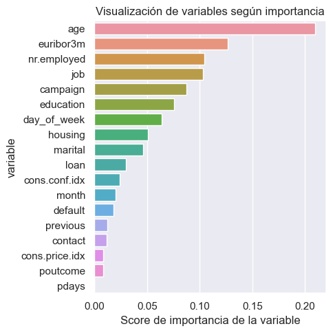

```python
# Analizamos cuáles son las variables más relevantes para nuestras predicciones.

feature_imp = pd.Series(DecisionTreeClassifier(max_depth = 21, random_state=201).fit(X_train, Y_train).feature_importances_, index=X_train.columns).sort_values(ascending=False)

plt.figure(figsize=(5,5))
sns.barplot(x=feature_imp, y=feature_imp.index)
plt.xlabel('Score de importancia de la variable')
plt.ylabel('variable')
plt.title("Visualización de variables según importancia")
plt.tight_layout()
```

Vemos que las variables 'age', 'euribor3m', 'nr.employed' y 'job' son las más relevantes para la predicción.

# V - Predicción

Una vez el modelo seleccionado, realizamos la predicción.

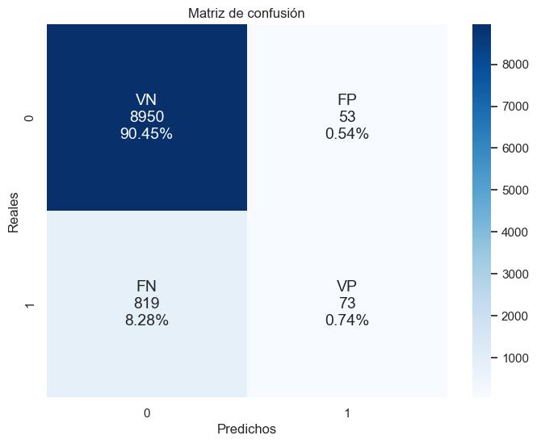

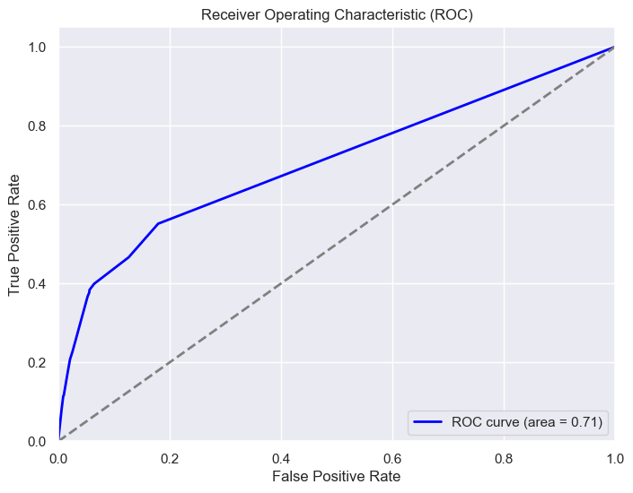

```
Tabla de resultados:
```

|  | Hiperparámetro | Matriz de confusión | AUC | Accuracy | Precisión | ECM |
| --- | --- | --- | --- | --- | --- | --- |
| 0 | max_depth=4 | [[8950, 53], [819, 73]] | 0.706551 | 0.911875 | 0.579365 | 0.088125 |

```python
# Creamos una función para preprocesar los datos
def preprocess_and_evaluate(data_cut_final, evalua_metodo):
    # Asignamos las variables que serán predictores y la predicha
    y = data_cut_final.loc[:, data_cut_final.columns == "y"]
    X = data_cut_final.loc[:, data_cut_final.columns != "y"]

    # Preseteo de las variables: Hago esto solo para probar, porque cada train y test se creará/particionará por CV.
    X_train, X_test, Y_train, Y_test = train_test_split(X, y, test_size=0.3, random_state=201)

    # Instanciamos y ajustamos el clasificador:
    clf = DecisionTreeClassifier(criterion='gini', splitter='best', max_depth=4)
    clf.fit(X_train, Y_train)

    # Realizamos las predicciones:
    predictions = clf.predict(X_test)
    predictions_score = clf.predict_proba(X_test)[:,1]

    # Evaluamos la precisión/accuracy:
    accuracy = accuracy_score(Y_test, predictions)

    # Aplicamos la función evalua_metodo
    evalua_metodo(X_train, X_test, Y_train, Y_test, DecisionTreeClassifier)

    return X_test, Y_test, predictions, predictions_score, accuracy

# Creamos una función para imprimir la matriz de confusión
def print_confusion_matrix(Y_test, predictions):
    mc = confusion_matrix(Y_test, predictions)
    group_names = ['VN','FP','FN','VP']
    group_counts = ["{0:0.0f}".format(value) for value in mc.flatten()]
    group_percentages = ["{0:.2%}".format(value) for value in mc.flatten()/np.sum(mc)]
    labels = [f"{v1}\n{v2}\n{v3}" for v1, v2, v3 in zip(group_names, group_counts, group_percentages)]
    labels = np.asarray(labels).reshape(2,2)
    plt.figure(figsize=(8, 6))
    sns.heatmap(mc, annot=labels, fmt='', cmap='Blues', annot_kws={"size": 14}).set(title='Matriz de confusión', xlabel='Predichos', ylabel='Reales')
    plt.show()

# Creamos una función para el ploteo de la curva ROC
def plot_roc_curve(Y_test, predictions_score):
    fpr, tpr, thresholds = roc_curve(Y_test, predictions_score)
    roc_auc_value = auc(fpr, tpr)  # Renamed variable to avoid conflict
    plt.figure(figsize=(8, 6))
    plt.plot(fpr, tpr, color='blue', lw=2, label='ROC curve (area = %0.2f)' % roc_auc_value)  # Updated variable name
    plt.plot([0, 1], [0, 1], color='gray', lw=2, linestyle='--')
    plt.xlim([0.0, 1.0])
    plt.ylim([0.0, 1.05])
    plt.xlabel('False Positive Rate')
    plt.ylabel('True Positive Rate')
    plt.title('Receiver Operating Characteristic (ROC)')
    plt.legend(loc='lower right')
    plt.show()


X_test, Y_test, predictions, predictions_score, accuracy = preprocess_and_evaluate(data_cut_final, evalua_metodo)

# Resultados

print_confusion_matrix(Y_test, predictions)
plot_roc_curve(Y_test, predictions_score)
conf_matrix = confusion_matrix(Y_test, predictions)
auc_value = roc_auc_score(Y_test, predictions_score)
precision = precision_score(Y_test, predictions)
mse = mean_squared_error(Y_test, predictions)

# Guardamos los resultados
results = pd.DataFrame({
    'Hiperparámetro': ['max_depth=4'],  # Update this with your actual hyperparameter
    'Matriz de confusión': [conf_matrix],
    'AUC': [auc_value],  # Updated variable name
    'Accuracy': [accuracy],
    'Precisión': [precision],
    'ECM': [mse]
})

# Mostramos los resultados

print('\nTabla de resultados: ')
display(results)
```

## VI - Conclusiones

Luego de nuestro análisis, concluimos lo siguiente:

### Modelo

El modelo que mejor performance tiene es el de los Árboles de Decisión, o Decision Trees Classifier, tal como lo muestran los resultados obtenidos:

[output not shown]

En particular, nuestro modelo obtuvo los siguientes resultados:

| Hiperparámetro | Matriz de confusión | AUC | Accuracy | Precisión | ECM |
| --- | --- | --- | --- | --- | --- |
| max_depth=4 | [[8950, 53], [819, 73]] | 0.706551 | 0.911875 | 0.579365 | 0.088125 |

### Variables

También, identificamos que las variables más relevantes para predecir la subscripción o no al servicio fueron:

- Edad ('age'),
- Tasa de interés EURIBOR de 3 meses, con frecuencia diaria ('euribor3m'),
- Cantidad de empleados ('nr.employed')
- Trabajo ('job').